# Profil Amplitude - Fréquence

##### Observation

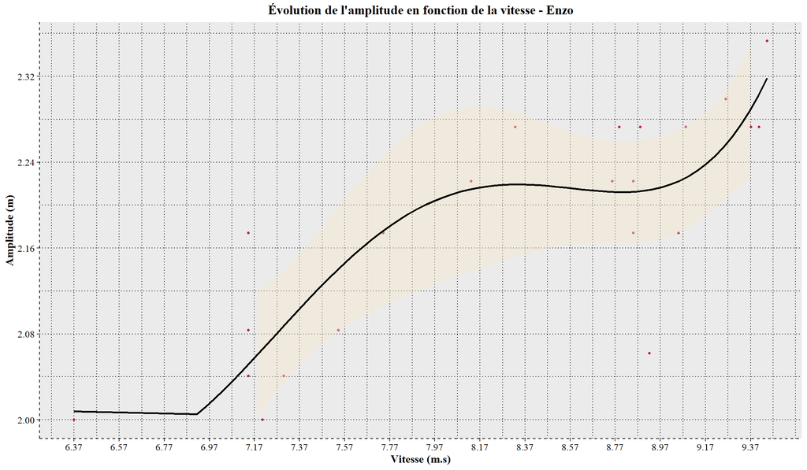

Graphique n°30 : Évolution de l’amplitude en fonction de la vitesse - Enzo

On note un ρ = 0.8***.

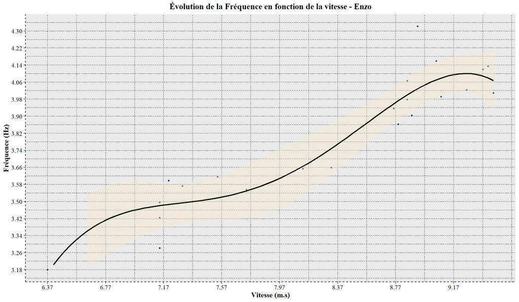

Graphique n°31 : Évolution de la Fréquence en fonction de la vitesse - Enzo

On note un r² de ρ = 0.93***.

**Matteo**

##### Observation

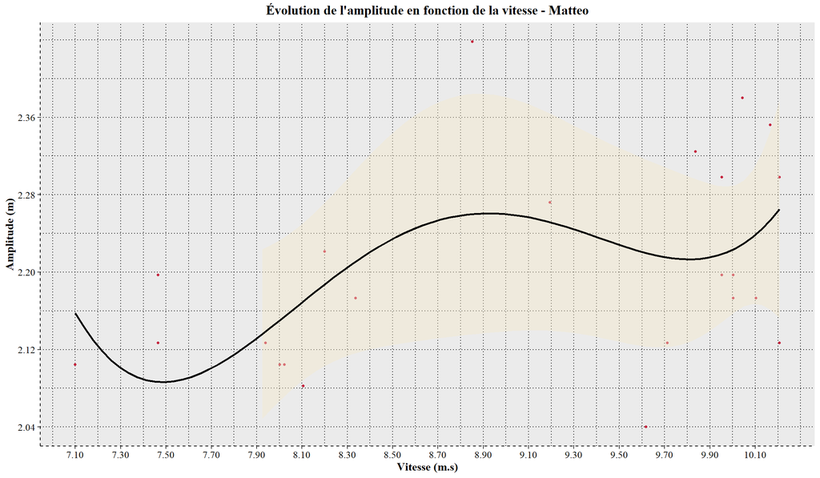

Graphique n°32 : Évolution de l’amplitude en fonction de la vitesse - Matteo

On note un ρ = 0.74***.

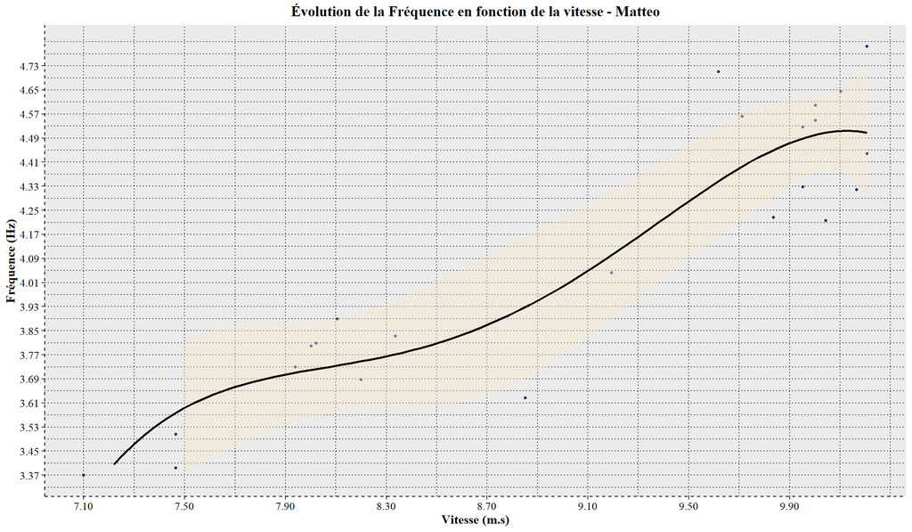

Graphique n°33 : Évolution de la Fréquence en fonction de la vitesse - Matteo

On note un r² de ρ = 0.94***.

**Chloé**

##### Observation

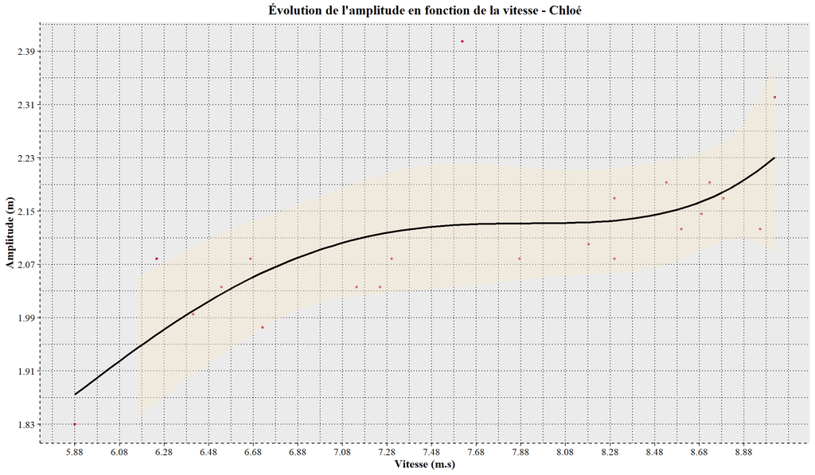

Graphique n°34 : Évolution de l’amplitude en fonction de la vitesse - Chloé

On note un ρ = 0.66**.

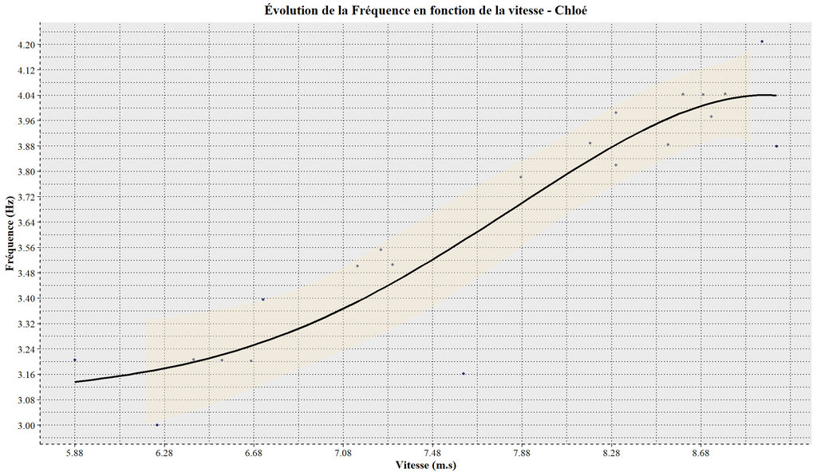

Graphique n°35 : Évolution de la Fréquence en fonction de la vitesse - Chloé

On note un r² de ρ = 0.93***.

**Grace**

##### Observation

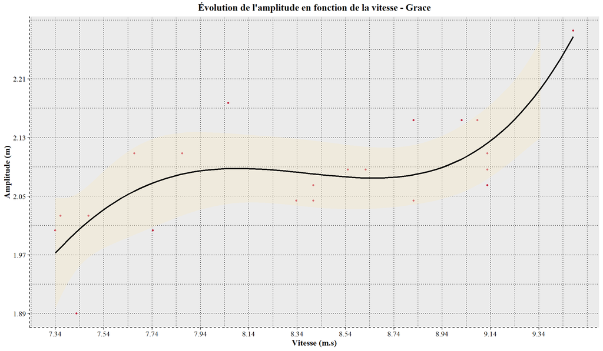

Graphique n°36 : Évolution de l’amplitude en fonction de la vitesse - Grace

On note un ρ = 0.64**.

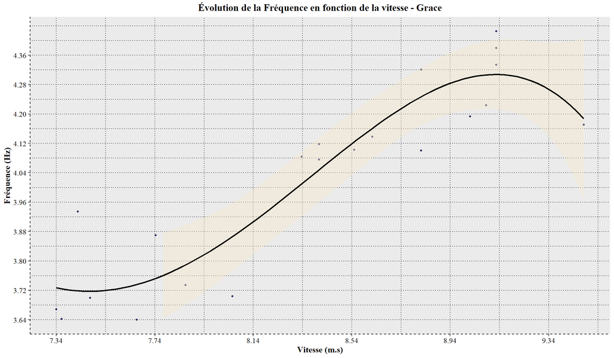

Graphique n°37 : Évolution de la Fréquence en fonction de la vitesse - Grace

On note un r² de ρ = 0.89***.

**Dylan**

##### Observation

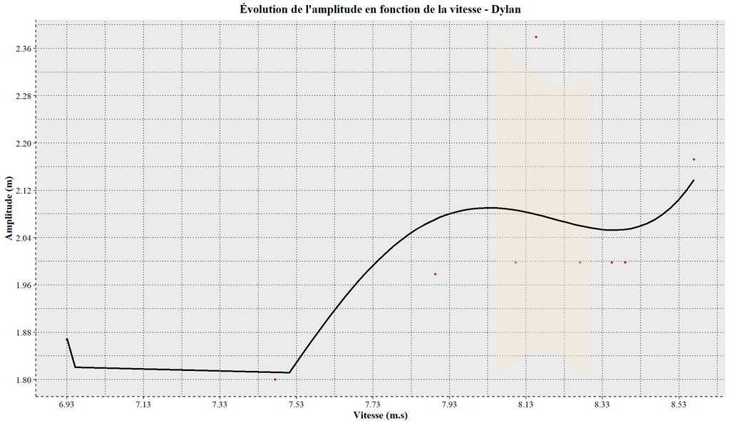

Graphique n°38 : Évolution de l’amplitude en fonction de la vitesse - Dylan

On note un ρ = 0.58ns.

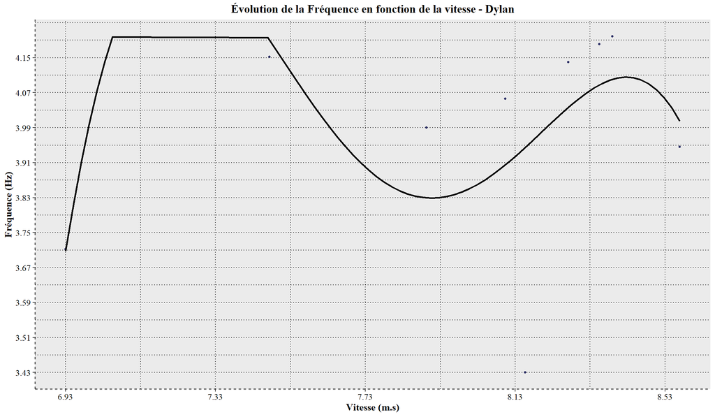

Graphique n°39 : Évolution de la Fréquence en fonction de la vitesse - Dylan

On note un r² de ρ = 0.28ns.

**Yacouba**

##### Observation

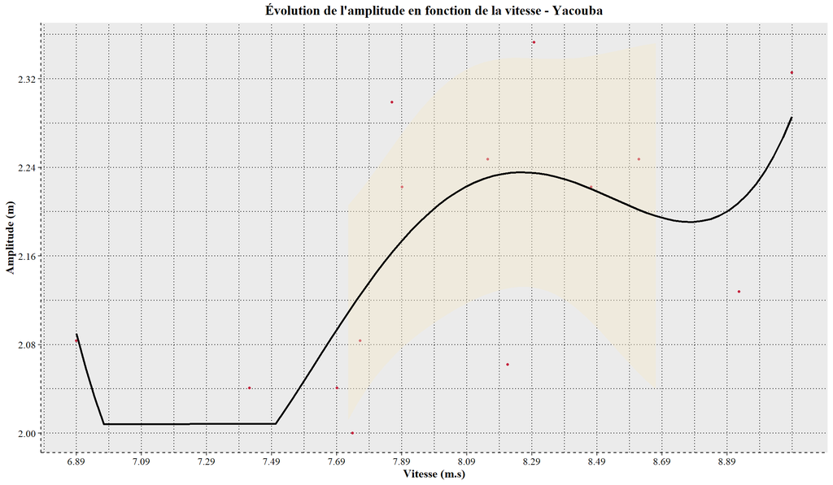

Graphique n°40 : Évolution de l’amplitude en fonction de la vitesse - Yacouba

On note un ρ = 0.55*.

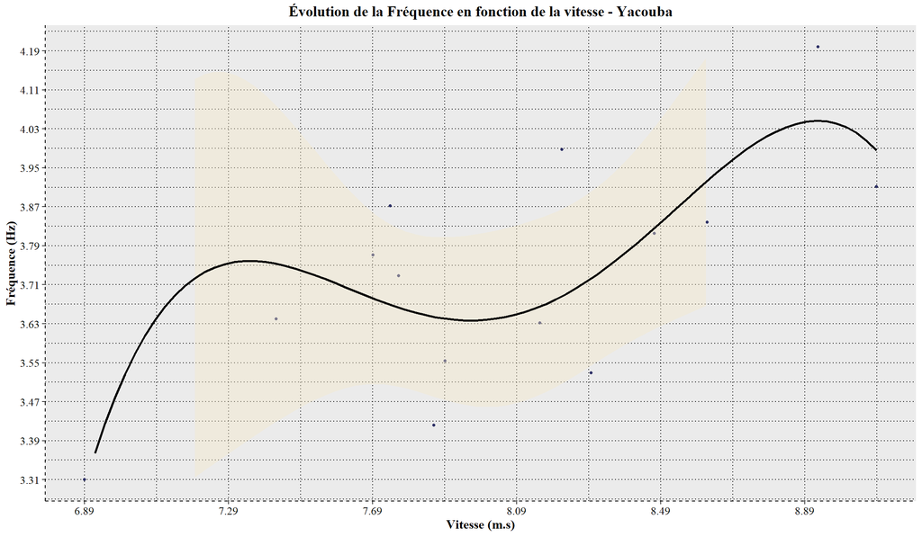

Graphique n°41 : Évolution de la Fréquence en fonction de la vitesse - Yacouba

On note un r² de ρ = 0.69**.

**Johanna**

##### Observation

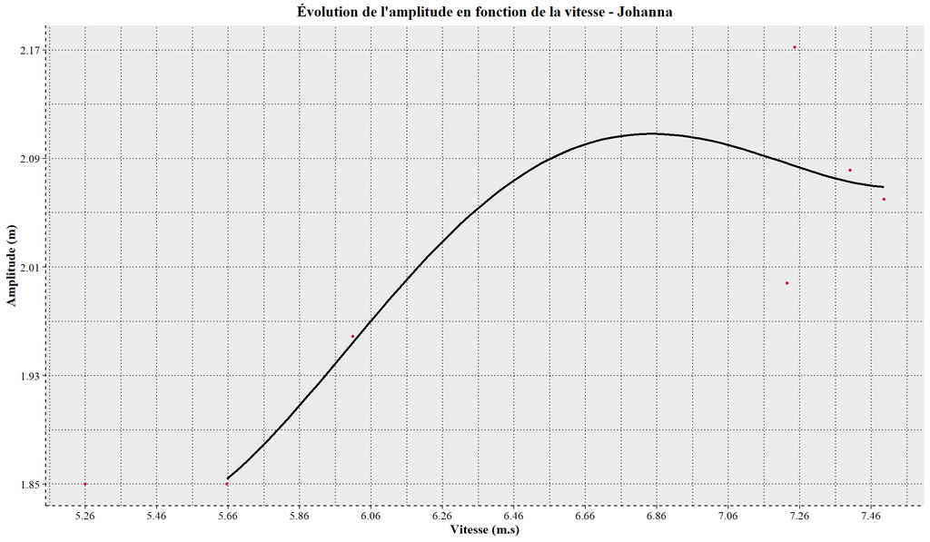

Graphique n°42 : Évolution de l’amplitude en fonction de la vitesse - Johanna

On note un ρ = 0.88**.

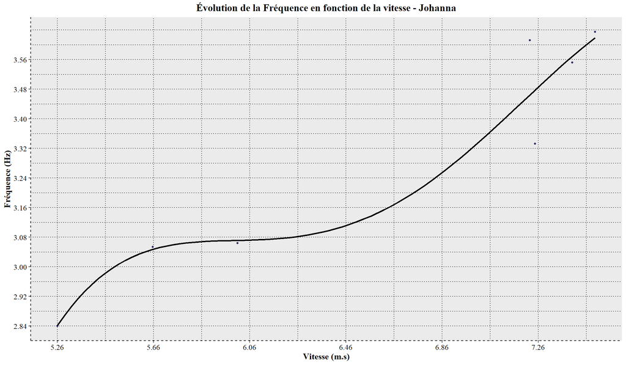

Graphique n°43 : Évolution de la Fréquence en fonction de la vitesse - Johanna

On note un r² de ρ = 0.96***.

**Oumar**

##### Observation

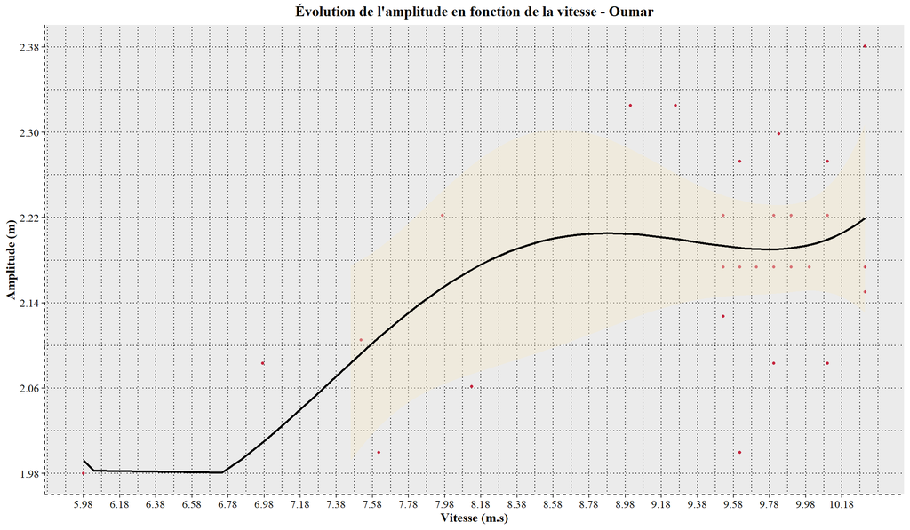

Graphique n°44 : Évolution de l’amplitude en fonction de la vitesse - Oumar

On note un ρ = 0.81*.

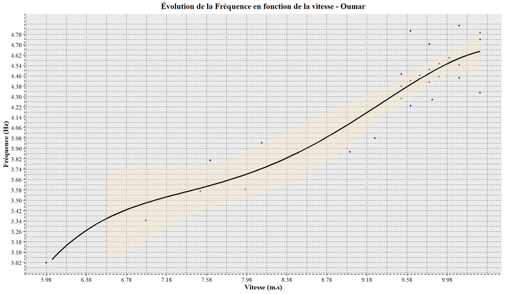

Graphique n°45 : Évolution de la Fréquence en fonction de la vitesse - Oumar

On note un r² de ρ = 0.95***.

**Mahine**

##### Observation

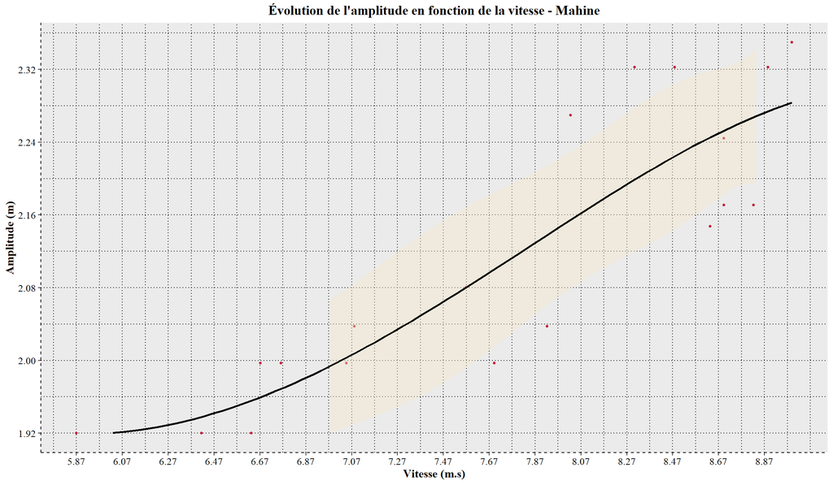

Graphique n°46 : Évolution de l’amplitude en fonction de la vitesse - Mahine

On note un ρ = 0.87***.

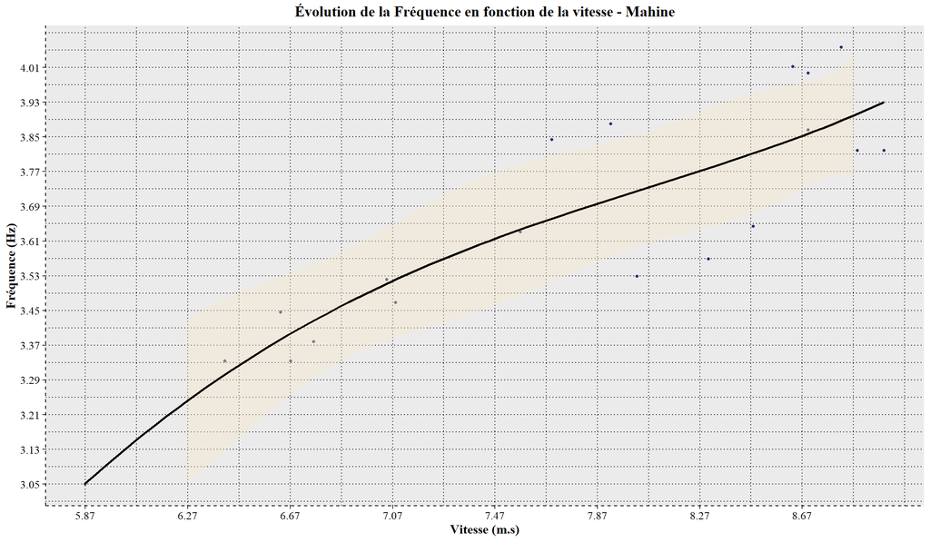

Graphique n°47 : Évolution de la Fréquence en fonction de la vitesse - Mahine

On note un r² de ρ = 0.88***.

**Estelle**

##### Observation

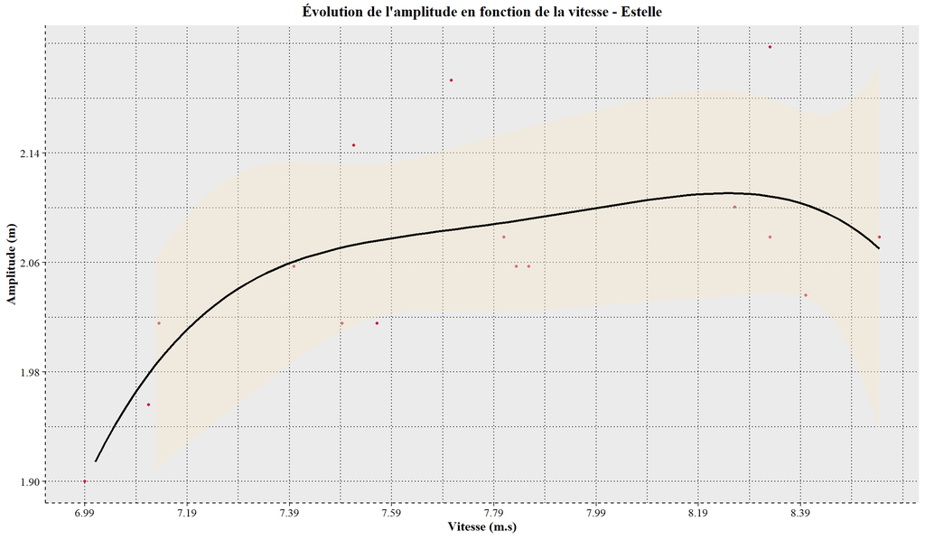

Graphique n°48 : Évolution de l’amplitude en fonction de la vitesse - Estelle

On note un ρ = 0.56*.

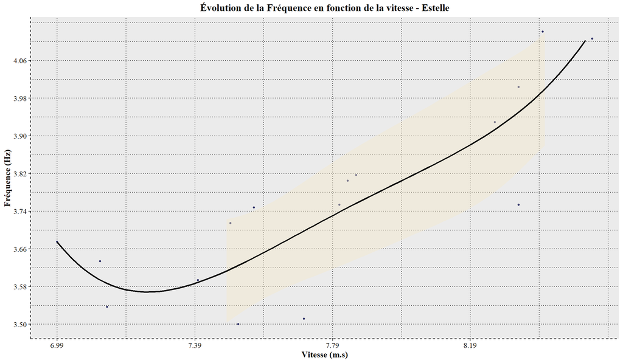

Graphique n°49 : Évolution de la Fréquence en fonction de la vitesse - Estelle

On note un r² de ρ = 0.81***.

**Profils**

**Paras**

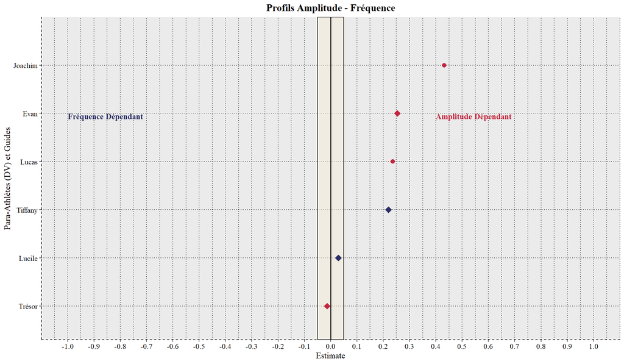

Graphique n°50 : Profils Amplitude - Fréquence - Paras

**Valides**

**Profils A-F**

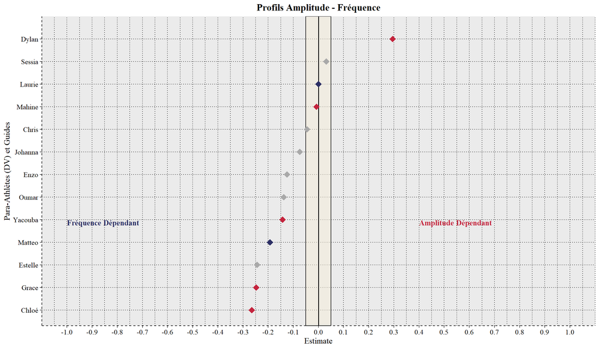

Graphique n°51 : Profils Amplitude - Fréquence - Valides

**Profils Locomoteurs**

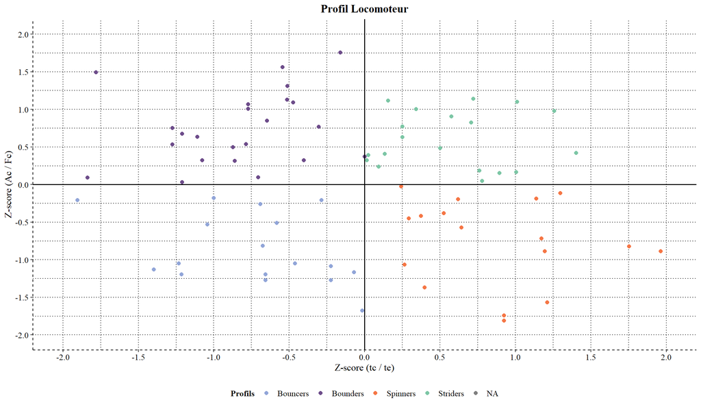

Graphique n°52 : Profil Locomoteur

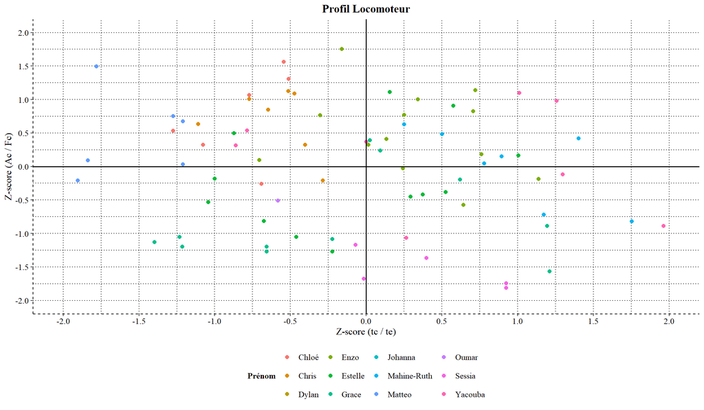

Graphique n°53 : Profil Locomoteur (Athlètes)

- Faire un schéma en fonction des PF-V,
- Faire un schéma en rajoutant la vitesse,
- Refaire toutes représentations et calculs en fonction de l’amplitude relative à la stature et à la longueur de jambe + avec la fréquence inverse.

**Pour aller plus loin…**

**Régressions…**